# Traveling Salesperson Problem

## Introduction

In this exercise, we will attempt to solve an instance of the traveling salesman problem (TSP) using different methods. The goal is to become familiar with evolutionary algorithms and to appreciate their effectiveness on a difficult search problem. We concentrate on writing our program from scratch.

|  | Barcelona | Belgrade | Berlin | Brussels | Bucharest | Budapest |
| --- | --- | --- | --- | --- | --- | --- |
| Barcelona | 0 | 1528.13 | 1497.61 | 1062.89 | 1968.42 | 1498.79 |
| Belgrade | 1528.13 | 0 | 999.25 | 1372.59 | 447.34 | 316.41 |
| Berlin | 1497.61 | 999.25 | 0 | 651.62 | 1293.40 | 1293.40 |
| Brussels | 1062.89 | 1372.59 | 651.62 | 0 | 1769.69 | 1131.52 |
| Bucharest | 1968.42 | 447.34 | 1293.40 | 1769.69 | 0 | 639.77 |
| Budapest | 1498.79 | 316.41 | 1293.40 | 1131.52 | 639.77 | 0 |

Figure 1: First 6 cities from csv file.

## Problem

The traveling salesperson, wishing to disturb the residents of the major cities in some region of the world in the shortest time possible, is faced with the problem of finding the shortest tour among the cities. A tour is a path that starts in one city, visits all of the other cities, and then returns to the starting point. The relevant pieces of information, then, are the cities and the distances between them. In this instance of the TSP, a number of European cities are to be visited. Their relative distances are given in the data file, *european_cities.csv*, found in the zip file with the mandatory assignment.

## Exhaustive Search

Firstly, we will try to solve the problem by inspecting every possible tour. Start by writing a program to find the shortest tour among a subset of the cities (say, **6** of them). Measure the amount of time your program takes. Incrementally add more cities and observe how the time increases.

```python
import numpy as np
import matplotlib.pyplot as plt
import pandas as pd
import itertools as it
import random as rd
import time
import csv
```

```python
data = pd.read_csv("european_cities.csv",sep=';').values.tolist()

def totalDistance(cityData,solution):
    #finds the totaldistance for a given solution.
    distance = 0
    for i in range(len(solution)):
        distance += cityData[solution[i-1]][solution[i]]
    return distance

def shortestPath(cityData,cityNum):
    bestDistance = 100000000
    bestSequence = None
    #using itertool to make permutations
    for perm in it.permutations(cityNum):
        #calculating the totalDistance for each permutations
        currentDistance = totalDistance(cityData,perm)
        #checking if the currentDistance is better than best, if thats
        #the case then it changes
        if currentDistance < bestDistance:
            bestDistance = currentDistance
            bestSequence = perm
    return bestDistance,perm
```

The shortest tour (i.e., the actual sequence of cities, and its length) among the first 10 cities (that is, the cities starting with B,C,D,H and I) is computed below.

```python
cityNum = range(10)
t1 = time.time()
best_distance,best_sequece = shortestPath(data,cityNum)
t2 = time.time()
finalTime = t2-t1
print(f"Best solution: {best_distance:.3f}")
print(f"The actual sequence of the citites: {best_sequece}")
print(f"Best time: {finalTime:.2f} s")
```

```
Best solution: 7486.310
The actual sequence of the citites: (9, 8, 7, 6, 5, 4, 3, 2, 1, 0)
Best time: 5.92 s
```

## Hill Climbing

We will try to solve the TSP by Hill Climbing algorithm.

```python
def randomSolution(cityData):
    #this function selects a random city
    cities = list(range(len(cityData)))
    solution = []

    for i in range(len(cityData)):
        #selecting a city randomly using randint
        #adding it in the list of solution
        #making sure to not select it again by removing it from cities
        randomCity = cities[rd.randint(0,len(cities)-1)]
        solution.append(randomCity)
        cities.remove(randomCity)

    return solution

def getNeighbors(solution):
    #this function returns all neighbors of the given solution
    #by recombination/swaping elements of the solution listl
    AllNeighbors = []
    for i in range(len(solution)):
        for j in range(i+1,len(solution)):
            neighbor = solution.copy()
            neighbor[i] = solution[j]
            neighbor[j] = solution[i]
            AllNeighbors.append(neighbor)
    return AllNeighbors


def getBestNeighbor(cityData,AllNeighbors):
    #initialising the current best distances and neighbors
    #this function finds the best neighbor (meaning neighbor with shortest distance)
    #by searching all of the neighbors
    bestDistance = totalDistance(cityData, AllNeighbors[0])
    bestNeighbor = AllNeighbors[0]
    for neighbor in AllNeighbors:
        currentDistance = totalDistance(cityData,neighbor)
        #checks if the currentDistance is better than the best, if so
        #it changes the best
        if currentDistance < bestDistance:
            bestDistance = currentDistance
            bestNeighbor = neighbor
    return bestNeighbor,bestDistance


def hillClimbing(cityData):
    #calling on the functions above to get the variables
    currentSolution = randomSolution(cityData)
    currentDistance = totalDistance(cityData,currentSolution)
    AllNeighbors = getNeighbors(currentSolution)
    bestNeighbor,bestDistance = getBestNeighbor(cityData,AllNeighbors)
    #checks if the currentDistance is better than the best, if so
    #it changes the best
    while bestDistance < currentDistance:
        currentSolution = bestNeighbor
        currentDistance = bestDistance
        AllNeighbors = getNeighbors(currentSolution)
        bestNeighbor,bestDistance = getBestNeighbor(cityData,AllNeighbors)

    return currentSolution,currentDistance
```

The hill climber performed very well compared to exhaustive search. We got almost the same distance. Hill climbing is a stochastic algorithm, so we had to run the algorithm several times to measure its performance. Although we ended up with the same result for the distance, but the sequel of the cities differs from the exhaustive search.

```python
amountRuns = 20
listFirstTen = []
listAllCities = []
for i in range(amountRuns):
    distanceForTen = hillClimbing(data[0:10])[1]
    listFirstTen.append(distanceForTen)

    distanceAll = hillClimbing(data)[1]
    listAllCities.append(distanceAll)

def printing(string,liste):
    print(f"Hill climbing: 20 runs of the {string}")
    print(f"Best length of the tour: {min(liste):.3f}")
    print(f"Worst length of the tour: {max(liste):.3f}")
    print(f"Mean length of the tour: {np.mean(liste):.3f}")
    print(f"Standard deviation of the runs: {np.std(liste):.3f}")
    print("___________________________________________")

printing("first ten cities",listFirstTen)
printing("all cities",listAllCities)
```

```
Hill climbing: 20 runs of the first ten cities
Best length of the tour: 7486.310
Worst length of the tour: 7737.950
Mean length of the tour: 7564.320
Standard deviation of the runs: 113.813
___________________________________________
Hill climbing: 20 runs of the all cities
Best length of the tour: 12504.080
Worst length of the tour: 15528.340
Mean length of the tour: 14368.179
Standard deviation of the runs: 855.119
___________________________________________
```

## Genetic Algorithm

Solving the TSP problem by Genetic algorithm. We choose a mutation and crossover operators that are appropriate for the problem.

### The procedure goes as following:

```python
def calulateDistance(data,combination):
    #calculates the distance btween cities and stores it
    finalDistance = 0
    for i in range(len(combination) - 1):
        fromCity = data[0].index(combination[i])
        toCity = data[0].index(combination[i + 1])
        distances = data[1:]
        distance = float(distances[fromCity][toCity])
        finalDistance += distance

    lastCity = data[0].index(combination[-1])
    firstCity = data[0].index(combination[0])
    lastDistance = float(data[1:][lastCity][firstCity])
    finalDistance += lastDistance
    return finalDistance


def calculateFitness(fitnessOfTour,population,distanceOfTour):
    #calculates fitness and stores it
    for i in range(len(population)):
        fitness = np.sum(distanceOfTour)/distanceOfTour[i]
        fitnessOfTour.append(fitness)
    return fitnessOfTour

def makeAPopulation(data,tourOfCities,populationSize):
    #creating a population by using the random.shuffle()
    distanceOfTour = []
    population = []
    fitnessOfTour = []
    for i in range(populationSize):
        tour = tourOfCities.copy()
        rd.shuffle(tour)

        population.append(tour)
        distanceOfTour.append(calulateDistance(data,tour))

    fitnessOfTour = calculateFitness(fitnessOfTour,population,distanceOfTour)

    return population,distanceOfTour,fitnessOfTour
```

```python
#Selection of parents
def parentSelection(population, fitnessOfTour):
    #defining the selectedParent as None
    selectedParent = None
    indeks = rd.randint(0, len(population) - 1)
    sumFitness = np.sum(fitnessOfTour)

    #loops until we find a parent
    while selectedParent == None:
        if indeks == len(population):
            indeks = 0
        #selecting the parent with highest fitness
        probability = fitnessOfTour[indeks]/sumFitness
        if probability > rd.uniform(0,1):
            selectedParent = population[indeks]
        indeks += 1

    return selectedParent

#Selection of the survivor:
def survivorSelection(population, populationSize, fitnessOfTour,distanceOfTour):
    fullPopulation = []
    #adding up population,fitness and distance in one list in order to make it easier for sorting
    for i in range(len(population)):
        fullPopulation.append([population[i],distanceOfTour[i],fitnessOfTour[i]])
    #sorting and revoming those with the worst fitness
    fullPopulation.sort(key=lambda x: x[2], reverse=True)
    while len(fullPopulation) > populationSize:
        fullPopulation.pop()

    population = [row[0] for row in fullPopulation]
    distanceOfTour = [row[1] for row in fullPopulation]
    fitnessOfTour = [row[2] for row in fullPopulation]

    return population,distanceOfTour,fitnessOfTour

#partially-mapped crossover
def pmx(a, b, start, stop):
    child = [None]*len(a)
    child[start:stop] = a[start:stop]
    for ind, x in enumerate(b[start:stop]):
        ind += start
        if x not in child:
            while child[ind] != None:
                ind = b.index(a[ind])
            child[ind] = x
    for ind, x in enumerate(child):
        if x == None:
            child[ind] = b[ind]

    return child

def pmxPair(a,b):
    half = len(a) // 2
    start = np.random.randint(0, len(a)-half)
    stop = start+half
    return pmx(a, b, start, stop), pmx(b, a, start, stop)

#mutation
def swapMutation(child):
    cities = np.random.choice(len(child), 2, replace=False)
    child[cities[0]], child[cities[1]] = child[cities[1]], child[cities[0]]
    return child


#this funciton generate parents and childs by mutation and crossover
def nextGeneration(population,fitnessOfTour,data,distanceOfTour):
    populationSize = len(population)
    listOffspring = []
    distOffspring = []
    fitOffspring = []

    for i in range(len(population)//2):
        #calling on and creating parents
        parent1 = parentSelection(population, fitnessOfTour)
        parent2 = parentSelection(population, fitnessOfTour)

        #mutation and crossover
        child1, child2 = pmxPair(parent1,parent2)
        child1 = swapMutation(child1)
        child2 = swapMutation(child2)

        #adding the children into the lists of offspring
        listOffspring.append(child1)
        distOffspring.append(calulateDistance(data,child1))
        fitOffspring.append(0)

        listOffspring.append(child2)
        distOffspring.append(calulateDistance(data,child2))
        fitOffspring.append(0)

    for i in range(len(listOffspring)):
        fitOffspring[i] = np.sum(distOffspring)/distOffspring[i]

    #adding offspring to the population
    population = population + listOffspring
    distanceOfTour = distanceOfTour + distOffspring
    fitnessOfTour = fitnessOfTour + fitOffspring

    return survivorSelection(population, populationSize, fitnessOfTour,distanceOfTour)


def evaluation(population,fitnessOfTour,data,distanceOfTour):
    bestDist = distanceOfTour
    bestRout = population
    bestFitness = fitnessOfTour

    generation = 0
    counter = 0

    #using while loop to find the best solution by running it many times, if it runs without
    #improving the programe will terminate
    while counter < 100:
        population,distanceOfTour,fitnessOfTour = nextGeneration(population,fitnessOfTour,data,distanceOfTour)
        generation += 1

        if distanceOfTour[0] < bestDist[0]:
            bestDist = distanceOfTour
            bestRout = population
            bestFitness = fitnessOfTour
            counter = 0
        else:
            counter += 1
    return bestRout,bestDist,bestFitness,generation
```

```
GA for 10 cities with populationSize =20:
Shortest distance: 7486.310
Mean distance: 7937.769
Standard deviation: 356.960
Worst distance: 8744.900
Time: 3.523 s
___________________________________________
GA for 10 cities with populationSize =40:
Shortest distance: 7486.310
Mean distance: 7730.195
Standard deviation: 226.066
Worst distance: 8309.610
Time: 7.074 s
___________________________________________
GA for 10 cities with populationSize =80:
Shortest distance: 7486.310
Mean distance: 7729.057
Standard deviation: 162.081
Worst distance: 8003.960
Time: 18.898 s
___________________________________________
```

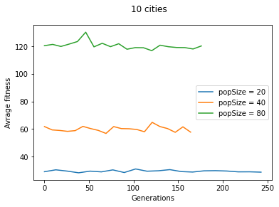

```
GA for 24 cities with populationSize =20:
Shortest distance: 15792.350
Mean distance: 17798.408
Standard deviation: 1354.247
Worst distance: 20856.140
Time: 5.777 s
___________________________________________
GA for 24 cities with populationSize =40:
Shortest distance: 13324.900
Mean distance: 16380.903
Standard deviation: 2100.358
Worst distance: 22381.750
Time: 15.641 s
___________________________________________
GA for 24 cities with populationSize =80:
Shortest distance: 13339.810
Mean distance: 15988.198
Standard deviation: 1767.268
Worst distance: 19201.320
Time: 36.208 s
___________________________________________
```

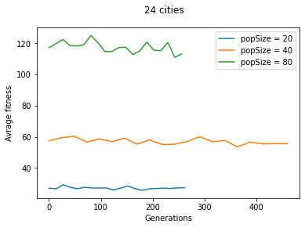

```python
def runningGA(populationSize,numberOfCities,data):
    t1 = time.time()
    tourOfCities = data[0][:numberOfCities]
    population,distanceOfTour,fitnessOfTour = makeAPopulation(data,tourOfCities,populationSize)

    bestSolution = []
    runs = []
    for i in range(20):
        bestRout,bestDist,bestFitness,generation = evaluation(population,fitnessOfTour,data,distanceOfTour)
        bestSolution.append([bestRout[0],bestDist[0],bestFitness[0]])
        runs.append(generation)

    t2 = time.time()

    bestSolution.sort(key=lambda x: x[1], reverse=False)
    avrageFitness = [x[2] for x in bestSolution]
    gen = np.linspace(0,max(runs),20)
    plt.plot(gen,avrageFitness,label = f"popSize = {populationSize}")

    print(f'GA for {numberOfCities} cities with populationSize ={populationSize}:')
    print(f'Shortest distance: {bestSolution[0][1]:.3f}')
    print(f'Mean distance: {np.mean([x[1] for x in bestSolution]):.3f}')
    print(f'Standard deviation: {np.std([x[1] for x in bestSolution]):.3f}')
    print(f'Worst distance: {bestSolution[-1][1]:.3f}')
    finalTime = t2-t1
    print(f"Time: {finalTime:.3f} s")
    print("___________________________________________")

def printing(popSizes,numCities):
    data = list(csv.reader(open("european_cities.csv", "r"), delimiter=";"))
    for p in popSizes:
        runningGA(p,numCities,data)

    plt.suptitle(f"{numCities} cities")
    plt.xlabel("Generations")
    plt.ylabel("Avrage fitness")
    plt.legend()
    plt.show()

printing([20,40,80],10)
printing([20,40,80],24)
```

### The plots

The plot above is showing the avrage fitness per generations. As it can be seen, the different graphs shows fitness for the given population sizes which are 20,40 and 80. Generally, the avrage fitness increase with the population size. In the plot of the ten first cities, we can see that the avrage fitness is quite stable at population size 20. In addition to this, we can also see that the standard deviation drops from 356.960 to 226.066 by changing the population size, and further decreases to 162.081 at population size 80. This clearly tells us that the best choice of population size is around 80 and it is the most stable one.

The interesting thing is that we get a different situation in the plot for 24 cities. Here we can see that the standard deviation increases with increasing population size from 20 to 40, but it drops again at population size 80. This can again be seen in the plot. Note that for 24 cities, the code struggles to find the very shortest distance between the cities, but it is getting close. Unfortunately, I was unable to fix this issue.

### Observations

We see from above that the shortest length was found to be 7486.310 which is the exactly same length as found with exhaustive search. This solution seems to be solid, since the very same distance was found by all different population sizes.

We can calculate the amount of tours completed by the genetic algorithm and the exhaustive search by following:

$$ GATours = (populationSize)\cdot(generationCount) \cdot (runs) $$$$ ExhaustiveTours = (numberOfCities)!$$

For the GA, I used population sizes 20, 40, 80 and run the program 20 times. The amount of avrage generation count after this runs was 130. This gives us:

$$ GATours = (140)\cdot(130) \cdot (20) = 364000$$$$ ExhaustiveTours = (numberOfCities)! = 10! = 3628800$$

Note that these numbers are not entirely accurate considering that the program can create duplicate children and parents, but may seem like a good approximation.